# Computer Vision Classification Project: Plant Seedlings

## Problem Statement

### Context

In recent times, the field of agriculture has been in urgent need of modernizing, since the amount of manual work people need to put in to check if plants are growing correctly is still highly extensive. Despite several advances in agricultural technology, people working in the agricultural industry still need to have the ability to sort and recognize different plants and weeds, which takes a lot of time and effort in the long term. The potential is ripe for this trillion-dollar industry to be greatly impacted by technological innovations that cut down on the requirement for manual labor, and this is where Artificial Intelligence can actually benefit the workers in this field, as **the time and energy required to identify plant seedlings will be greatly shortened by the use of AI and Deep Learning.** The ability to do so far more efficiently and even more effectively than experienced manual labor, could lead to better crop yields, the freeing up of human inolvement for higher-order agricultural decision making, and in the long term will result in more sustainable environmental practices in agriculture as well.

### Objective

The aim of this project is to Build a Convolutional Neural Network to classify plant seedlings into their respective categories.

### Data Dictionary

The Aarhus University Signal Processing group, in collaboration with the University of Southern Denmark, has recently released a dataset containing **images of unique plants belonging to 12 different species.**

- The dataset can be download from Olympus.
- The data file names are:
  - images.npy
  - Labels.csv
- Due to the large volume of data, the images were converted to the images.npy file and the labels are also put into Labels.csv, so that you can work on the data/project seamlessly without having to worry about the high data volume.
- The goal of the project is to create a classifier capable of determining a plant's species from an image.

**List of Species**

- Black-grass
- Charlock
- Cleavers
- Common Chickweed
- Common Wheat
- Fat Hen
- Loose Silky-bent
- Maize
- Scentless Mayweed
- Shepherds Purse
- Small-flowered Cranesbill
- Sugar beet

## Install additional libraries

```python
# Install libraries for tensorflow
!pip install tensorflow
```

## Importing necessary libraries

```python
# Import libraries for data manipulation
import re
import random
import numpy as np
import pandas as pd

# Import libraries for image processing
import cv2

# Import libraries for error handling
import warnings

# Import libraries for data visualization
import matplotlib.pyplot as plt
import seaborn as sns

#Import libraries for statistics
from scipy.stats import *

# Import libraries for scikit-learn
import sklearn as skl
from sklearn.tree import *
from sklearn.model_selection import *
from sklearn.metrics import *
from sklearn.preprocessing import *

# Import libraries for sampling
import imblearn as imb
from imblearn.over_sampling import *
from imblearn.under_sampling import *

# Import libraries for tensorflow
import tensorflow as tf
from tensorflow.keras import *
from tensorflow.keras.models import *
from tensorflow.keras.layers import *
from tensorflow.keras.backend import *
from tensorflow.keras.metrics import *
from tensorflow.keras.optimizers import *
from tensorflow.keras.callbacks import *
from tensorflow.keras.preprocessing.image import *
from tensorflow.keras.applications import *
from tensorflow.keras.utils import *

# Import libraries for keras
from keras.applications.vgg16 import *
```

```python
# Apply settings

# Ignore warnings
warnings.filterwarnings('ignore')

# Set limit for the displayed columns in a DataFrame
pd.set_option('display.max_columns', 50)

# Set precision of floating numbers to 5 decimal points
pd.set_option('display.float_format', lambda x: '%.5f' % x)

# Set fixed seed for random number generators
random_state = 1

random.seed(random_state)
np.random.seed(random_state)
tf.random.set_seed(random_state)
```

## Loading the dataset

```python
# Load the images
images = np.load('/content/plants_images.npy')

# Read the labels
labels = pd.read_csv('/content/plants_images.csv')
```

## Data Overview

```python
# Display the data of images dataset
images
```

```
array([[[[ 35,  52,  78],
         [ 36,  49,  76],
         [ 31,  45,  69],
         ...,
         [ 78,  95, 114],
         [ 76,  93, 110],
         [ 80,  95, 109]],

        [[ 33,  46,  68],
         [ 37,  50,  73],
         [ 48,  65,  83],
         ...,
         [ 81,  96, 113],
         [ 74,  89, 105],
         [ 83,  95, 109]],

        [[ 34,  50,  68],
         [ 35,  52,  72],
         [ 70,  85, 101],
         ...,
         [ 83,  97, 112],
         [ 79,  94, 108],
         [ 79,  94, 107]],

        ...,

        [[ 35,  50,  69],
         [ 42,  57,  73],
         [ 42,  57,  72],
         ...,
         [ 60,  76,  92],
         [ 67,  81,  97],
         [ 64,  77,  95]],

        [[ 36,  52,  67],
         [ 48,  63,  78],
         [ 41,  57,  73],
         ...,
         [ 44,  66,  83],
         [ 58,  76,  91],
```

[output cut: 252 more lines]

```
        [[ 59,  75,  89],
         [ 57,  74,  91],
         [ 57,  79,  96],
         ...,
         [ 34,  56,  79],
         [ 71,  90, 102],
         [ 72,  89, 104]],

        [[ 68,  85, 103],
         [ 66,  80,  96],
         [ 67,  86, 100],
         ...,
         [ 70,  87, 101],
         [ 68,  82,  95],
         [ 68,  84, 101]]]], dtype=uint8)
```

```python
# Display the data of labels dataset
labels
```

|  | Label |
| --- | --- |
| 0 | Small-flowered Cranesbill |
| 1 | Small-flowered Cranesbill |
| 2 | Small-flowered Cranesbill |
| 3 | Small-flowered Cranesbill |
| 4 | Small-flowered Cranesbill |
| ... | ... |
| 4745 | Loose Silky-bent |
| 4746 | Loose Silky-bent |
| 4747 | Loose Silky-bent |
| 4748 | Loose Silky-bent |
| 4749 | Loose Silky-bent |

4750 rows × 1 columns

```python
# Display the shape of the images dataset
images.shape
```

```
(4750, 128, 128, 3)
```

```python
# Display the rows and shape of the labels dataset
labels.shape
```

```
(4750, 1)
```

```python
# Display the data type of the images dataset
images.dtype
```

```
dtype('uint8')
```

```python
# Display the size of the images dataset
images.size * images.itemsize
```

```
233472000
```

```python
# Display the summary of the labels dataset
labels.info()
```

```
<class 'pandas.core.frame.DataFrame'>
RangeIndex: 4750 entries, 0 to 4749
Data columns (total 1 columns):
 #   Column  Non-Null Count  Dtype
---  ------  --------------  -----
 0   Label   4750 non-null   object
dtypes: object(1)
memory usage: 37.2+ KB
```

```python
# Display how many missing values are present in the images dataset
np.isnan(images).sum()
```

```
0
```

```python
# Display how many missing values are present in the labels dataset
labels.isna().sum()
```

```
Label    0
dtype: int64
```

```python
# Display the count of unique categorical values in each column of the labels dataset
print(labels['Label'].value_counts(dropna = False))
```

```
Label
Loose Silky-bent             654
Common Chickweed             611
Scentless Mayweed            516
Small-flowered Cranesbill    496
Fat Hen                      475
Charlock                     390
Sugar beet                   385
Cleavers                     287
Black-grass                  263
Shepherds Purse              231
Common wheat                 221
Maize                        221
Name: count, dtype: int64
```

```python
# Display the percentage of unique categorical values in each column of the labels dataset
print(labels['Label'].value_counts(normalize = True, dropna = False).mul(100))
```

```
Label
Loose Silky-bent            13.76842
Common Chickweed            12.86316
Scentless Mayweed           10.86316
Small-flowered Cranesbill   10.44211
Fat Hen                     10.00000
Charlock                     8.21053
Sugar beet                   8.10526
Cleavers                     6.04211
Black-grass                  5.53684
Shepherds Purse              4.86316
Common wheat                 4.65263
Maize                        4.65263
Name: proportion, dtype: float64
```

**Observations:**

- The images dataset has 4,750 records of 128 x 128 x 3 dimensions of image data that contain pixel values of the RGB images.
- The labels dataset has 4,750 records with 1 column that contains the equivalent labels of the images dataset.
- The size of the images dataset is 233.5 MB, while the size of the labels dataset is 37.2 KB.
- There are no missing values in both the images and labels dataset.
- There is 1 data type in the images dataset:
  - unit8 (4750): All records
- There is 1 data type in the labels dataset:
  - object (4750): Label
- The column Label of the labels dataset contains 12 unique values:
  - Loose Silky-bent - 654
  - Common Chickweed - 611
  - Scentless Mayweed - 516
  - Small-flowered Cranesbill - 496
  - Fat Hen - 475
  - Charlock - 390
  - Sugar beet - 385
  - Cleavers - 287
  - Black-grass - 263
  - Shepherds Purse - 231
  - Common wheat - 221
  - Maize - 221

## Exploratory Data Analysis

### Function Definition

```python
# User-defined functions
def show_images(images, labels, rows = 3, cols = 4, figsize = (10, 8)):
  '''
  Description: Function to show the images (in random) of the image data
  Parameters:
    images: numpy.ndarray, required
      The array of pixels of the image data
    labels: pandas.core.frame.DataFrame, required
      The class labels of the image data
    rows: int, optional
      The number of rows to use when displayig the images, default: 3
    cols: int, optional
      The number of columns to use when displayig the images, default: 4
    figsize: tuple, optional
      The figure size in inches, default: (10, 8)
  '''
  keys = dict(labels)
  figure = plt.figure(figsize = figsize)

  for col in range(cols):
      for row in range(rows):
          random_index = np.random.randint(0, len(labels))
          ax = figure.add_subplot(rows, cols, col * rows + row + 1)
          ax.imshow(images[random_index, :])
          ax.set_title(keys[random_index], fontsize = 11)
  plt.show()

def show_countplot(data, feature, hue = None, n = None, ascending = False, figsize = (11.75, 5)):
  '''
  Description: Function to plot a barplot with labeled percentage or count
  Parameters:
    data: pandas.core.frame.DataFrame, required
      The DataFrame of the two-dimensional tabular data
    feature: str, required
      Name of the feature column
    hue: str, optional
      To show the hue, default: None
    n: int, optional
      To show the top n category levels, default: None (display all levels)
    ascending: bool, optional
      To sort the bar by count, default: False
    figsize: tuple, optional
      The figure size in inches, default: (11.75, 5)
  '''
  total = len(data[feature])
  count = data[feature].nunique()
  order = data[feature].value_counts().index.tolist()[:n]

  if ascending == True:
    order.reverse()

  plt.figure(figsize = figsize)
  plt.xticks(rotation = 90)
  plt.xlim(0, data[feature].value_counts().tolist()[0] * 1.5)

  if hue == None:
    hue = feature

  ax = sns.countplot(data = data, y = feature, hue = hue, palette = 'Paired', order = order, legend = False)

  ax.set_title('Number of ' + feature, fontsize = 11)

  for patch in ax.patches:
    x = patch.get_x() + patch.get_width()
    y = patch.get_y() + patch.get_height() / 1.75
    cnt = ('{:.0f}').format(patch.get_width())
    pct = ('{:.2f}%').format(100 * patch.get_width() / len(data))

    ax.annotate(cnt + ' (' + pct + ')', (x, y), ha = 'left', va = 'center', xytext = (0, 2.5), textcoords = 'offset points')

  plt.show()
```

### Univariate Analysis

##### Observations on Labels:

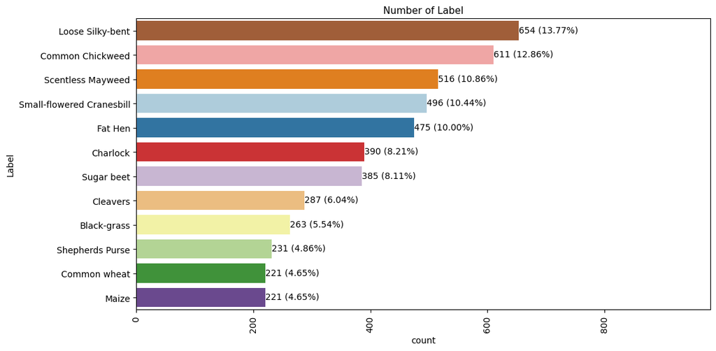

```python
# Display the number of plants with regards to Label
show_countplot(data = labels, feature = 'Label', figsize = (11.75, 6))
```

**Observations:**

- Label shows a higher number of plants belonging to Loose Silky-bent (with 654 or 13.76%). List is followed by:
  - Common Chickweed (with 611 or 12.86%)
  - Scentless Mayweed (with 516 or 10.86%)
  - Small-flowered Cranesbill (with 496 or 10.44%)
  - Fat Hen (with 475 or 10.00%)
  - Charlock (with 390 or 8.21%)
  - Sugar beet (with 385 or 8.10%)
  - Cleavers (with 287 or 6.04%)
  - Black-grass (with 263 or 5.53%)
  - Shepherds Purse (with 231 or 4.86%)
  - Common wheat (with 221 or 4.65%)
  - Maize (with 221 or 4.65%)
- The dataset shows imbalanced data.

### Visualizing Images

##### Observations on Images:

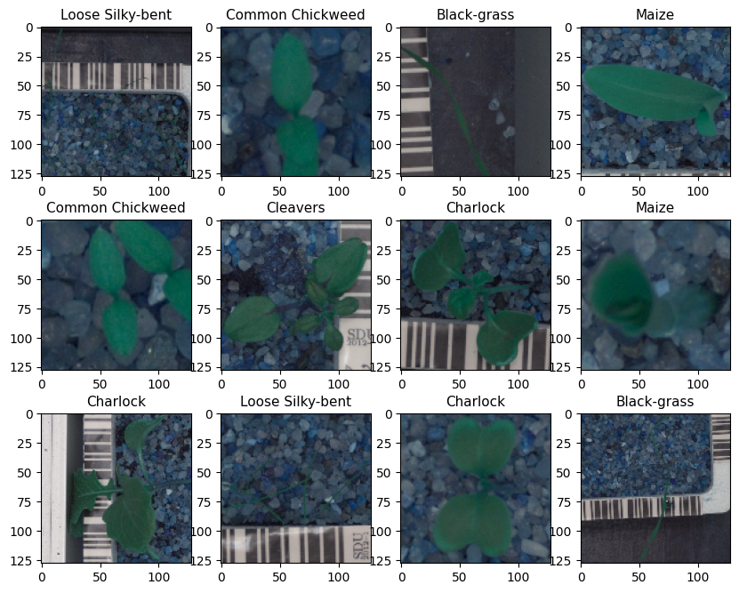

```python
# Display random images from each of the class
show_images(images = images, labels = labels['Label'])
```

**Observations:**

- Images shows 128 x 128 pixels of plant images.
- Images contain pixel data in BGR format and need to be converted RGB format.
- Some of the plants are small and not very visible. They also have different objects/ noises in the background (e.g. stones, soil, barcode/ labels, etc).

### Key Observations on Exploratory Data Analysis

- Label shows imbalanced data and a higher number of plants belonging to Loose Silky-bent (with 654 or 13.76%). List is followed by:
  - Common Chickweed (with 611 or 12.86%)
  - Scentless Mayweed (with 516 or 10.86%)
  - Small-flowered Cranesbill (with 496 or 10.44%)
  - Fat Hen (with 475 or 10.00%)
  - Charlock (with 390 or 8.21%)
  - Sugar beet (with 385 or 8.10%)
  - Cleavers (with 287 or 6.04%)
  - Black-grass (with 263 or 5.53%)
  - Shepherds Purse (with 231 or 4.86%)
  - Common wheat (with 221 or 4.65%)
  - Maize (with 221 or 4.65%)
- Images shows 128 x 128 pixels of plant images in BGR format and need to be converted to RGB format.
- Some of the plants are small and not very visible. They also have different objects/ noises in the background (e.g. stones, soil, barcode/ labels, etc).

## Data Preprocessing

### Image Conversion (BGR to RGB)

```python
# Create a copy of the images
images_modelling = images.copy()
```

```
ndarray (128, 128, 3)
```

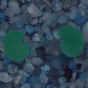

```
array([[[ 35,  52,  78],
        [ 36,  49,  76],
        [ 31,  45,  69],
        ...,
        [ 78,  95, 114],
        [ 76,  93, 110],
        [ 80,  95, 109]],

       [[ 33,  46,  68],
        [ 37,  50,  73],
        [ 48,  65,  83],
        ...,
        [ 81,  96, 113],
        [ 74,  89, 105],
        [ 83,  95, 109]],

       [[ 34,  50,  68],
        [ 35,  52,  72],
        [ 70,  85, 101],
        ...,
        [ 83,  97, 112],
        [ 79,  94, 108],
        [ 79,  94, 107]],

       ...,

       [[ 35,  50,  69],
        [ 42,  57,  73],
        [ 42,  57,  72],
        ...,
        [ 60,  76,  92],
        [ 67,  81,  97],
        [ 64,  77,  95]],

       [[ 36,  52,  67],
        [ 48,  63,  78],
        [ 41,  57,  73],
        ...,
        [ 44,  66,  83],
        [ 58,  76,  91],
        [ 57,  74,  90]],

       [[ 44,  58,  70],
        [ 43,  57,  73],
        [ 40,  55,  72],
        ...,
        [ 41,  70,  92],
        [ 55,  78,  97],
        [ 61,  79,  96]]], dtype=uint8)
```

```python
# Display sample image before conversion
images_modelling[0]
```

```python
# Convert images from BGR to RGB
for i in range(len(images_modelling)):
  images_modelling[i] = cv2.cvtColor(images_modelling[i], cv2.COLOR_BGR2RGB)
```

```
ndarray (128, 128, 3)
```

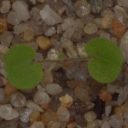

```
array([[[ 78,  52,  35],
        [ 76,  49,  36],
        [ 69,  45,  31],
        ...,
        [114,  95,  78],
        [110,  93,  76],
        [109,  95,  80]],

       [[ 68,  46,  33],
        [ 73,  50,  37],
        [ 83,  65,  48],
        ...,
        [113,  96,  81],
        [105,  89,  74],
        [109,  95,  83]],

       [[ 68,  50,  34],
        [ 72,  52,  35],
        [101,  85,  70],
        ...,
        [112,  97,  83],
        [108,  94,  79],
        [107,  94,  79]],

       ...,

       [[ 69,  50,  35],
        [ 73,  57,  42],
        [ 72,  57,  42],
        ...,
        [ 92,  76,  60],
        [ 97,  81,  67],
        [ 95,  77,  64]],

       [[ 67,  52,  36],
        [ 78,  63,  48],
        [ 73,  57,  41],
        ...,
        [ 83,  66,  44],
        [ 91,  76,  58],
        [ 90,  74,  57]],

       [[ 70,  58,  44],
        [ 73,  57,  43],
        [ 72,  55,  40],
        ...,
        [ 92,  70,  41],
        [ 97,  78,  55],
        [ 96,  79,  61]]], dtype=uint8)
```

```python
# Display sample image after conversion
images_modelling[0]
```

**Observations:**

- Image conversion from BGR to RGB format shows that images now contain more brownish color.

### Resize Images

```
ndarray (128, 128, 3)
```

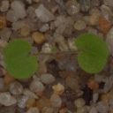

```
array([[[ 78,  52,  35],
        [ 76,  49,  36],
        [ 69,  45,  31],
        ...,
        [114,  95,  78],
        [110,  93,  76],
        [109,  95,  80]],

       [[ 68,  46,  33],
        [ 73,  50,  37],
        [ 83,  65,  48],
        ...,
        [113,  96,  81],
        [105,  89,  74],
        [109,  95,  83]],

       [[ 68,  50,  34],
        [ 72,  52,  35],
        [101,  85,  70],
        ...,
        [112,  97,  83],
        [108,  94,  79],
        [107,  94,  79]],

       ...,

       [[ 69,  50,  35],
        [ 73,  57,  42],
        [ 72,  57,  42],
        ...,
        [ 92,  76,  60],
        [ 97,  81,  67],
        [ 95,  77,  64]],

       [[ 67,  52,  36],
        [ 78,  63,  48],
        [ 73,  57,  41],
        ...,
        [ 83,  66,  44],
        [ 91,  76,  58],
        [ 90,  74,  57]],

       [[ 70,  58,  44],
        [ 73,  57,  43],
        [ 72,  55,  40],
        ...,
        [ 92,  70,  41],
        [ 97,  78,  55],
        [ 96,  79,  61]]], dtype=uint8)
```

```python
# Display sample image and size before conversion
images_modelling[0]
```

```python
# Display the size of the image before resizing
images_modelling[0].size * images_modelling[0].itemsize
```

```
49152
```

```python
# Resize the image from 128 x 128 pixel to 64 x 64 pixel
images_resized = []

for i in range(len(images_modelling)):
  images_resized.append(cv2.resize(src = images_modelling[i], dsize = (64, 64), interpolation = cv2.INTER_LINEAR))

images_modelling = images_resized
```

```python
# Display sample image and size after conversion
images_modelling[0]
```

```
ndarray (64, 64, 3)
```

```
array([[[ 74,  49,  35],
        [ 83,  65,  49],
        [ 99,  82,  67],
        ...,
        [106,  91,  75],
        [112,  95,  79],
        [108,  93,  78]],

       [[ 72,  52,  34],
        [104,  88,  72],
        [114,  97,  80],
        ...,
        [102,  86,  72],
        [108,  93,  79],
        [108,  95,  80]],

       [[ 77,  56,  38],
        [100,  83,  67],
        [113,  95,  78],
        ...,
        [ 98,  83,  69],
        [105,  90,  76],
        [106,  92,  80]],

       ...,

       [[ 66,  43,  31],
        [ 67,  49,  33],
        [ 68,  50,  38],
        ...,
        [ 88,  67,  54],
        [ 96,  79,  62],
        [ 95,  76,  65]],

       [[ 71,  51,  37],
        [ 74,  58,  44],
        [ 73,  56,  46],
        ...,
        [ 81,  59,  45],
        [ 90,  73,  58],
        [ 97,  80,  67]],

       [[ 72,  58,  43],
        [ 73,  57,  41],
        [ 72,  56,  41],
        ...,
        [ 71,  45,  29],
        [ 85,  64,  39],
        [ 94,  77,  58]]], dtype=uint8)
```

```python
# Display the size of the image after resizing
images_modelling[0].size * images_modelling[0].itemsize
```

```
12288
```

### Train-Validation-Test Split

```python
# Create independent variable
x = np.array(images_modelling)

# Create dependent variable
y = labels
```

```python
# Split the training, testing, and validation data
x_temp, x_test, y_temp, y_test = train_test_split(x, y, test_size = 0.1, random_state = random_state, stratify = y)

x_train, x_val, y_train, y_val = train_test_split(x_temp, y_temp, test_size = 0.1, random_state = random_state, stratify = y_temp)
```

```python
# Display the shape of training data
x_train.shape
```

```
(3847, 64, 64, 3)
```

```python
# Display the shape of validation data
x_val.shape
```

```
(428, 64, 64, 3)
```

```python
# Display the shape of testing data
x_test.shape
```

```
(475, 64, 64, 3)
```

**Observations:**

- The training data has a shape of 3,847 records of 64 x 64 x 3 dimensions of image data, while the validation and testing data have 428 and 475 records of 64 x 64 x 3 dimensions of image data.

### Label Encoding

```python
# Encode the values of the label training, testing, and validation data
lb = LabelBinarizer()

y_train_ec = lb.fit_transform(y_train)
y_val_ec = lb.transform(y_val)
y_test_ec = lb.transform(y_test)
```

```python
# Display the shape of the label training data
y_train_ec.shape
```

```
(3847, 12)
```

```python
# Display the shape of the label validation data
y_val_ec.shape
```

```
(428, 12)
```

```python
# Display the shape of the label testing data
y_test_ec.shape
```

```
(475, 12)
```

```python
# Display the equivalent encoded value for each category
y_train_ri = y_train.reset_index().copy()

display(lb.fit_transform(y_train_ec)[y_train_ri[y_train_ri['Label'].eq('Black-grass') == True].index[0]])
display(lb.fit_transform(y_train_ec)[y_train_ri[y_train_ri['Label'].eq('Charlock') == True].index[0]])
display(lb.fit_transform(y_train_ec)[y_train_ri[y_train_ri['Label'].eq('Cleavers') == True].index[0]])
display(lb.fit_transform(y_train_ec)[y_train_ri[y_train_ri['Label'].eq('Common Chickweed') == True].index[0]])
display(lb.fit_transform(y_train_ec)[y_train_ri[y_train_ri['Label'].eq('Common wheat') == True].index[0]])
display(lb.fit_transform(y_train_ec)[y_train_ri[y_train_ri['Label'].eq('Fat Hen') == True].index[0]])
display(lb.fit_transform(y_train_ec)[y_train_ri[y_train_ri['Label'].eq('Loose Silky-bent') == True].index[0]])
display(lb.fit_transform(y_train_ec)[y_train_ri[y_train_ri['Label'].eq('Maize') == True].index[0]])
display(lb.fit_transform(y_train_ec)[y_train_ri[y_train_ri['Label'].eq('Scentless Mayweed') == True].index[0]])
display(lb.fit_transform(y_train_ec)[y_train_ri[y_train_ri['Label'].eq('Shepherds Purse') == True].index[0]])
display(lb.fit_transform(y_train_ec)[y_train_ri[y_train_ri['Label'].eq('Small-flowered Cranesbill') == True].index[0]])
display(lb.fit_transform(y_train_ec)[y_train_ri[y_train_ri['Label'].eq('Sugar beet') == True].index[0]])
```

```
array([1, 0, 0, 0, 0, 0, 0, 0, 0, 0, 0, 0])
```

```
array([0, 1, 0, 0, 0, 0, 0, 0, 0, 0, 0, 0])
```

```
array([0, 0, 1, 0, 0, 0, 0, 0, 0, 0, 0, 0])
```

```
array([0, 0, 0, 1, 0, 0, 0, 0, 0, 0, 0, 0])
```

```
array([0, 0, 0, 0, 1, 0, 0, 0, 0, 0, 0, 0])
```

```
array([0, 0, 0, 0, 0, 1, 0, 0, 0, 0, 0, 0])
```

```
array([0, 0, 0, 0, 0, 0, 1, 0, 0, 0, 0, 0])
```

```
array([0, 0, 0, 0, 0, 0, 0, 1, 0, 0, 0, 0])
```

```
array([0, 0, 0, 0, 0, 0, 0, 0, 1, 0, 0, 0])
```

```
array([0, 0, 0, 0, 0, 0, 0, 0, 0, 1, 0, 0])
```

```
array([0, 0, 0, 0, 0, 0, 0, 0, 0, 0, 1, 0])
```

```
array([0, 0, 0, 0, 0, 0, 0, 0, 0, 0, 0, 1])
```

**Observations:**

- Label encoding shows that nominal labels have been translated into binary labels:
  - Black-grass = [1, 0, 0, 0, 0, 0, 0, 0, 0, 0, 0, 0]
  - Charlock = [0, 1, 0, 0, 0, 0, 0, 0, 0, 0, 0, 0]
  - Cleavers = [0, 0, 1, 0, 0, 0, 0, 0, 0, 0, 0, 0]
  - Common Chickweed = [0, 0, 0, 1, 0, 0, 0, 0, 0, 0, 0, 0]
  - Common wheat = [0, 0, 0, 0, 1, 0, 0, 0, 0, 0, 0, 0]
  - Fat Hen = [0, 0, 0, 0, 0, 1, 0, 0, 0, 0, 0, 0]
  - Loose Silky-bent = [0, 0, 0, 0, 0, 0, 1, 0, 0, 0, 0, 0]
  - Maize = [0, 0, 0, 0, 0, 0, 0, 1, 0, 0, 0, 0]
  - Scentless Mayweed = [0, 0, 0, 0, 0, 0, 0, 0, 1, 0, 0, 0]
  - Shepherds Purse = [0, 0, 0, 0, 0, 0, 0, 0, 0, 1, 0, 0]
  - Small-flowered Cranesbill = [0, 0, 0, 0, 0, 0, 0, 0, 0, 0, 1, 0]
  - Sugar beet = [0, 0, 0, 0, 0, 0, 0, 0, 0, 0, 0, 1]

### Data Normalization

```python
# Display the training data before normalization
x_train
```

```
array([[[[ 57,  74,  32],
         [ 63,  77,  40],
         [ 61,  76,  38],
         ...,
         [ 65,  80,  42],
         [ 64,  78,  43],
         [ 68,  81,  48]],

        [[ 59,  73,  36],
         [ 60,  71,  33],
         [ 60,  74,  35],
         ...,
         [ 65,  79,  42],
         [ 66,  79,  46],
         [ 65,  79,  47]],

        [[ 59,  71,  35],
         [ 61,  70,  35],
         [ 62,  74,  39],
         ...,
         [ 66,  79,  44],
         [ 66,  77,  45],
         [ 64,  75,  42]],

        ...,

        [[ 63,  31,  20],
         [ 65,  33,  20],
         [ 68,  36,  24],
         ...,
         [ 60,  39,  30],
         [ 66,  44,  33],
         [ 70,  46,  32]],

        [[ 59,  33,  18],
         [ 65,  39,  25],
         [ 74,  49,  37],
         ...,
         [ 65,  44,  35],
         [ 65,  43,  33],
```

[output cut: 252 more lines]

```
        [[ 75,  58,  47],
         [ 83,  69,  55],
         [ 83,  66,  54],
         ...,
         [ 42,  27,  22],
         [ 63,  55,  49],
         [ 91,  85,  77]],

        [[ 78,  61,  46],
         [ 75,  57,  39],
         [ 91,  74,  57],
         ...,
         [ 53,  42,  34],
         [ 65,  58,  52],
         [ 92,  87,  78]]]], dtype=uint8)
```

```python
# Display the validation data before normalization
x_val
```

```
array([[[[ 80,  53,  40],
         [104,  76,  48],
         [108,  78,  48],
         ...,
         [107,  90,  66],
         [ 86,  65,  45],
         [ 75,  53,  41]],

        [[ 91,  69,  52],
         [109,  79,  50],
         [115,  85,  56],
         ...,
         [118, 103,  78],
         [102,  82,  57],
         [ 94,  70,  50]],

        [[105,  92,  79],
         [102,  76,  56],
         [ 98,  69,  45],
         ...,
         [101,  77,  58],
         [106,  78,  56],
         [103,  78,  56]],

        ...,

        [[102,  87,  75],
         [ 91,  70,  46],
         [ 99,  69,  45],
         ...,
         [124, 113,  91],
         [125, 111,  86],
         [100,  83,  65]],

        [[ 74,  48,  34],
         [ 78,  53,  32],
         [110,  70,  35],
         ...,
         [109,  88,  65],
         [122, 106,  82],
```

[output cut: 252 more lines]

```
        [[107,  88,  71],
         [109,  92,  76],
         [108,  91,  75],
         ...,
         [ 83,  67,  59],
         [ 82,  69,  60],
         [ 84,  71,  61]],

        [[107,  87,  67],
         [108,  89,  71],
         [107,  89,  72],
         ...,
         [ 87,  69,  62],
         [ 88,  74,  65],
         [ 85,  72,  63]]]], dtype=uint8)
```

```python
# Display the testing data before normalization
x_test
```

```
array([[[[102,  82,  53],
         [104,  88,  56],
         [108,  91,  63],
         ...,
         [113,  95,  77],
         [114,  98,  79],
         [108,  90,  72]],

        [[112,  91,  65],
         [109,  91,  63],
         [111,  94,  65],
         ...,
         [109,  92,  72],
         [106,  90,  69],
         [106,  91,  71]],

        [[112,  91,  67],
         [114,  97,  73],
         [114,  98,  73],
         ...,
         [110,  94,  75],
         [106,  87,  70],
         [112, 102,  85]],

        ...,

        [[106,  94,  74],
         [104,  92,  75],
         [106,  98,  77],
         ...,
         [ 82,  65,  48],
         [ 93,  79,  63],
         [ 96,  80,  62]],

        [[104,  95,  74],
         [105,  93,  76],
         [107,  95,  76],
         ...,
         [ 82,  64,  44],
         [ 73,  53,  35],
```

[output cut: 252 more lines]

```
        [[ 95,  76,  63],
         [ 97,  80,  64],
         [ 96,  79,  63],
         ...,
         [ 82,  73,  59],
         [ 84,  72,  59],
         [ 83,  69,  60]],

        [[ 91,  74,  57],
         [ 93,  76,  58],
         [ 98,  81,  65],
         ...,
         [ 77,  62,  50],
         [ 84,  67,  54],
         [ 81,  65,  55]]]], dtype=uint8)
```

```python
# Normalize the values of the feature training, testing, and validation data
x_train_nm = x_train.astype('float32') / 255.0
x_val_nm = x_val.astype('float32') / 255.0
x_test_nm = x_test.astype('float32') / 255.0
```

```python
# Display the training data after normalization
x_train_nm
```

```
array([[[[0.22352941, 0.2901961 , 0.1254902 ],
         [0.24705882, 0.3019608 , 0.15686275],
         [0.23921569, 0.29803923, 0.14901961],
         ...,
         [0.25490198, 0.3137255 , 0.16470589],
         [0.2509804 , 0.30588236, 0.16862746],
         [0.26666668, 0.31764707, 0.1882353 ]],

        [[0.23137255, 0.28627452, 0.14117648],
         [0.23529412, 0.2784314 , 0.12941177],
         [0.23529412, 0.2901961 , 0.13725491],
         ...,
         [0.25490198, 0.30980393, 0.16470589],
         [0.25882354, 0.30980393, 0.18039216],
         [0.25490198, 0.30980393, 0.18431373]],

        [[0.23137255, 0.2784314 , 0.13725491],
         [0.23921569, 0.27450982, 0.13725491],
         [0.24313726, 0.2901961 , 0.15294118],
         ...,
         [0.25882354, 0.30980393, 0.17254902],
         [0.25882354, 0.3019608 , 0.1764706 ],
         [0.2509804 , 0.29411766, 0.16470589]],

        ...,

        [[0.24705882, 0.12156863, 0.07843138],
         [0.25490198, 0.12941177, 0.07843138],
         [0.26666668, 0.14117648, 0.09411765],
         ...,
         [0.23529412, 0.15294118, 0.11764706],
         [0.25882354, 0.17254902, 0.12941177],
         [0.27450982, 0.18039216, 0.1254902 ]],

        [[0.23137255, 0.12941177, 0.07058824],
         [0.25490198, 0.15294118, 0.09803922],
         [0.2901961 , 0.19215687, 0.14509805],
         ...,
         [0.25490198, 0.17254902, 0.13725491],
         [0.25490198, 0.16862746, 0.12941177],
```

[output cut: 252 more lines]

```
        [[0.29411766, 0.22745098, 0.18431373],
         [0.3254902 , 0.27058825, 0.21568628],
         [0.3254902 , 0.25882354, 0.21176471],
         ...,
         [0.16470589, 0.10588235, 0.08627451],
         [0.24705882, 0.21568628, 0.19215687],
         [0.35686275, 0.33333334, 0.3019608 ]],

        [[0.30588236, 0.23921569, 0.18039216],
         [0.29411766, 0.22352941, 0.15294118],
         [0.35686275, 0.2901961 , 0.22352941],
         ...,
         [0.20784314, 0.16470589, 0.13333334],
         [0.25490198, 0.22745098, 0.20392157],
         [0.36078432, 0.34117648, 0.30588236]]]], dtype=float32)
```

```python
# Display the validation data after normalization
x_val_nm
```

```
array([[[[0.3137255 , 0.20784314, 0.15686275],
         [0.40784314, 0.29803923, 0.1882353 ],
         [0.42352942, 0.30588236, 0.1882353 ],
         ...,
         [0.41960785, 0.3529412 , 0.25882354],
         [0.3372549 , 0.25490198, 0.1764706 ],
         [0.29411766, 0.20784314, 0.16078432]],

        [[0.35686275, 0.27058825, 0.20392157],
         [0.42745098, 0.30980393, 0.19607843],
         [0.4509804 , 0.33333334, 0.21960784],
         ...,
         [0.4627451 , 0.40392157, 0.30588236],
         [0.4       , 0.32156864, 0.22352941],
         [0.36862746, 0.27450982, 0.19607843]],

        [[0.4117647 , 0.36078432, 0.30980393],
         [0.4       , 0.29803923, 0.21960784],
         [0.38431373, 0.27058825, 0.1764706 ],
         ...,
         [0.39607844, 0.3019608 , 0.22745098],
         [0.41568628, 0.30588236, 0.21960784],
         [0.40392157, 0.30588236, 0.21960784]],

        ...,

        [[0.4       , 0.34117648, 0.29411766],
         [0.35686275, 0.27450982, 0.18039216],
         [0.3882353 , 0.27058825, 0.1764706 ],
         ...,
         [0.4862745 , 0.44313726, 0.35686275],
         [0.49019608, 0.43529412, 0.3372549 ],
         [0.39215687, 0.3254902 , 0.25490198]],

        [[0.2901961 , 0.1882353 , 0.13333334],
         [0.30588236, 0.20784314, 0.1254902 ],
         [0.43137255, 0.27450982, 0.13725491],
         ...,
         [0.42745098, 0.34509805, 0.25490198],
         [0.47843137, 0.41568628, 0.32156864],
```

[output cut: 252 more lines]

```
        [[0.41960785, 0.34509805, 0.2784314 ],
         [0.42745098, 0.36078432, 0.29803923],
         [0.42352942, 0.35686275, 0.29411766],
         ...,
         [0.3254902 , 0.2627451 , 0.23137255],
         [0.32156864, 0.27058825, 0.23529412],
         [0.32941177, 0.2784314 , 0.23921569]],

        [[0.41960785, 0.34117648, 0.2627451 ],
         [0.42352942, 0.34901962, 0.2784314 ],
         [0.41960785, 0.34901962, 0.28235295],
         ...,
         [0.34117648, 0.27058825, 0.24313726],
         [0.34509805, 0.2901961 , 0.25490198],
         [0.33333334, 0.28235295, 0.24705882]]]], dtype=float32)
```

```python
# Display the testing data after normalization
x_test_nm
```

```
array([[[[0.4       , 0.32156864, 0.20784314],
         [0.40784314, 0.34509805, 0.21960784],
         [0.42352942, 0.35686275, 0.24705882],
         ...,
         [0.44313726, 0.37254903, 0.3019608 ],
         [0.44705883, 0.38431373, 0.30980393],
         [0.42352942, 0.3529412 , 0.28235295]],

        [[0.4392157 , 0.35686275, 0.25490198],
         [0.42745098, 0.35686275, 0.24705882],
         [0.43529412, 0.36862746, 0.25490198],
         ...,
         [0.42745098, 0.36078432, 0.28235295],
         [0.41568628, 0.3529412 , 0.27058825],
         [0.41568628, 0.35686275, 0.2784314 ]],

        [[0.4392157 , 0.35686275, 0.2627451 ],
         [0.44705883, 0.38039216, 0.28627452],
         [0.44705883, 0.38431373, 0.28627452],
         ...,
         [0.43137255, 0.36862746, 0.29411766],
         [0.41568628, 0.34117648, 0.27450982],
         [0.4392157 , 0.4       , 0.33333334]],

        ...,

        [[0.41568628, 0.36862746, 0.2901961 ],
         [0.40784314, 0.36078432, 0.29411766],
         [0.41568628, 0.38431373, 0.3019608 ],
         ...,
         [0.32156864, 0.25490198, 0.1882353 ],
         [0.3647059 , 0.30980393, 0.24705882],
         [0.3764706 , 0.3137255 , 0.24313726]],

        [[0.40784314, 0.37254903, 0.2901961 ],
         [0.4117647 , 0.3647059 , 0.29803923],
         [0.41960785, 0.37254903, 0.29803923],
         ...,
         [0.32156864, 0.2509804 , 0.17254902],
         [0.28627452, 0.20784314, 0.13725491],
```

[output cut: 252 more lines]

```
        [[0.37254903, 0.29803923, 0.24705882],
         [0.38039216, 0.3137255 , 0.2509804 ],
         [0.3764706 , 0.30980393, 0.24705882],
         ...,
         [0.32156864, 0.28627452, 0.23137255],
         [0.32941177, 0.28235295, 0.23137255],
         [0.3254902 , 0.27058825, 0.23529412]],

        [[0.35686275, 0.2901961 , 0.22352941],
         [0.3647059 , 0.29803923, 0.22745098],
         [0.38431373, 0.31764707, 0.25490198],
         ...,
         [0.3019608 , 0.24313726, 0.19607843],
         [0.32941177, 0.2627451 , 0.21176471],
         [0.31764707, 0.25490198, 0.21568628]]]], dtype=float32)
```

**Observations:**

- Data normalization shows that the pixel values have been scaled from a minimum of 0 (black) to a maximum of 1 (white).

## Model Building

### Function Definition

```python
# User-defined functions
def show_lineplot(data_train, data_val, feature_name, labels, loc = 'upper left', figsize = (8, 5)):
  '''
  Description: Function to plot a histogram and a boxplot with hue along the same scale
  Parameters:
    data_train: list, required
      The list of training data
    data_val: list, required
      The list of validation data
    labels: list, optional
      The list of labels for training/ validation data
    loc: str, optional
      The location of the label, default: upper left
    figsize: tuple, optional
      The figure size in inches, default: (11.75, 5)
  '''
  plt.figure(figsize = figsize)
  plt.plot(data_train)
  plt.plot(data_val)
  plt.title('Model ' + feature_name)
  plt.ylabel(feature_name)
  plt.xlabel('Epoch')
  plt.legend(labels = labels, loc = loc)

  plt.show()

def show_confusion_matrix_multiclass(target, predictors, title = '', figsize = (10, 8)):
  '''
  Description: Function to plot a histogram and a boxplot with hue along the same scale
  Parameters:
    target: pandas.core.series.Series, required
      The values of actual data
    predictors: pandas.core.series.Series, required
      The values of predicted data
  '''
  cm = tf.math.confusion_matrix(target, predictors)
  f, ax = plt.subplots(figsize = figsize)

  ax.set_title('Confusion Matrix ' + title, fontsize = 11)
  sns.heatmap(
      cm,
      annot = True,
      linewidths = 0.4,
      fmt = 'd',
      square = True,
      ax = ax
  )

  plt.show()

def show_classification_report(model_name, target_train, predictors_train, target_val = None, predictors_val = None, target_test = None, predictors_test = None):
  '''
  Description: Function to plot a histogram and a boxplot with hue along the same scale
  Parameters:
    model_name: pstring, required
      The name of the model
    target_train: pandas.core.series.Series, required
      The values of actual training data
    predictors_train: pandas.core.series.Series, required
      The values of predicted training data
    target_val: pandas.core.series.Series, optional
      The values of actual validation data
    predictors_val: pandas.core.series.Series, optional
      The values of predicted validation data
    target_test: pandas.core.series.Series, optional
      The values of actual testing data
    predictors_test: pandas.core.series.Series, optional
      The values of predicted testing data
  '''
  df_train = pd.DataFrame(classification_report(target_train, predictors_train, output_dict = True)).transpose()
  df_train.loc['accuracy', 'support'] = df_train.loc['weighted avg', 'support']
  df_train.loc['accuracy', ['precision', 'recall']] = ''

  df_cr = pd.concat({'{} (Training)'.format(model_name): df_train}, axis = 1)

  if target_val is not None and predictors_val is not None:
    df_val = pd.DataFrame(classification_report(target_val, predictors_val, output_dict = True)).transpose()
    df_val.loc['accuracy', 'support'] = df_val.loc['weighted avg', 'support']
    df_val.loc['accuracy', ['precision', 'recall']] = ''

    df_cr = pd.concat({'{} (Training)'.format(model_name): df_train, '{} (Validation)'.format(model_name): df_val}, axis = 1)

  if target_test is not None and predictors_test is not None:
    df_test = pd.DataFrame(classification_report(target_test, predictors_test, output_dict = True)).transpose()
    df_test.loc['accuracy', 'support'] = df_test.loc['weighted avg', 'support']
    df_test.loc['accuracy', ['precision', 'recall']] = ''

    if target_val is None and predictors_val is None:
      df_cr = pd.concat({'{} (Training)'.format(model_name): df_train, '{} (Testing)'.format(model_name): df_test}, axis = 1)
    else:
      df_cr = pd.concat({'{} (Training)'.format(model_name): df_train, '{} (Validation)'.format(model_name): df_val, '{} (Testing)'.format(model_name): df_test}, axis = 1)

  display(df_cr)

def show_model_accuracy_comp(metric_list):
  '''
  Description: Function to display the accuracy performance
  Parameters:
    models: list, required
      The list containing: metric name, model, x_train_data, y_train_data, x_val_data, y_val_data, x_test_data, y_test_data
  '''
  metric_names = []
  metric_perfs = []

  for metric_name, model, x_train_data, y_train_data, x_val_data, y_val_data, x_test_data, y_test_data in metric_list:

    accuracy_train = model.evaluate(x_train_data, y_train_data, verbose = 0)
    perf_dc = {'Accuracy (Training)': accuracy_train[1]}

    if x_val_data is not None and y_val_data is not None:
      accuracy_val = model.evaluate(x_val_data, y_val_data, verbose = 0)
      perf_dc['Accuracy (Validation)'] = accuracy_val[1]
      perf_dc['Difference (Training - Validation)'] = accuracy_val[1] - accuracy_train[1]

    if x_test_data is not None and y_test_data is not None:
      accuracy_test = model.evaluate(x_test_data, y_test_data, verbose = 0)
      perf_dc['Accuracy (Testing)'] = accuracy_test[1]
      perf_dc['Difference (Training - Testing)'] = accuracy_test[1] - accuracy_train[1]

    df_perf = pd.DataFrame(perf_dc, index = [0])

    metric_perfs.append(df_perf.transpose())
    metric_names.append(metric_name)

  model_comps = pd.concat(metric_perfs, axis = 1)
  model_comps.columns = metric_names

  display(model_comps)
```

### Convolutional Neural Network

##### Sequential model with CNN using normalized data

```python
# Clear backend session
clear_session()

# Create model with CNN using normalized data
model_name_0 = 'CNN using normalized data'

model_0 = Sequential()

model_0.add(Conv2D(filters = 8, kernel_size = (3, 3), activation = 'relu', padding = 'same', input_shape = (64, 64, 3)))
model_0.add(MaxPooling2D(pool_size = (2, 2), padding = 'same'))

model_0.add(Conv2D(filters = 8, kernel_size = (3, 3), activation = 'relu', padding = 'same'))
model_0.add(MaxPooling2D(pool_size = (2, 2), padding = 'same'))

model_0.add(Conv2D(filters = 8, kernel_size = (3, 3), activation = 'relu', padding = 'same'))
model_0.add(MaxPooling2D(pool_size = (2, 2), padding = 'same'))

model_0.add(Flatten())

model_0.add(Dense(units = 12, activation = 'softmax'))

model_0.compile(optimizer = Adam(learning_rate = 0.0001), loss = 'categorical_crossentropy', metrics = ['accuracy'])

model_0.summary()
```

```
Model: "sequential"
_________________________________________________________________
 Layer (type)                Output Shape              Param #
=================================================================
 conv2d (Conv2D)             (None, 64, 64, 8)         224

 max_pooling2d (MaxPooling2  (None, 32, 32, 8)         0
 D)

 conv2d_1 (Conv2D)           (None, 32, 32, 8)         584

 max_pooling2d_1 (MaxPoolin  (None, 16, 16, 8)         0
 g2D)

 conv2d_2 (Conv2D)           (None, 16, 16, 8)         584

 max_pooling2d_2 (MaxPoolin  (None, 8, 8, 8)           0
 g2D)

 flatten (Flatten)           (None, 512)               0

 dense (Dense)               (None, 12)                6156

=================================================================
Total params: 7548 (29.48 KB)
Trainable params: 7548 (29.48 KB)
Non-trainable params: 0 (0.00 Byte)
_________________________________________________________________
```

```python
%%time

# Fit the model
history_0 = model_0.fit(
  x_train_nm, y_train_ec,
  batch_size = 100,
  validation_data = (x_val_nm, y_val_ec),
  epochs = 150,
  verbose = 1
)
```

```
CPU times: user 1min 2s, sys: 6.92 s, total: 1min 9s
Wall time: 1min 24s
```

##### Observations on Sequential model with CNN using normalized data

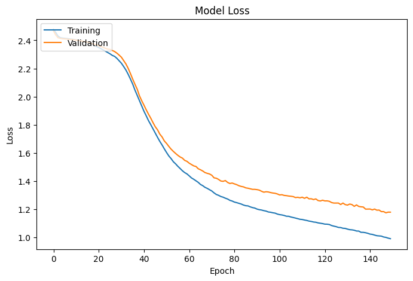

```python
# Display the training loss and validation loss
show_lineplot(data_train = history_0.history['loss'], data_val = history_0.history['val_loss'], feature_name = 'Loss', labels = ['Training', 'Validation'])
```

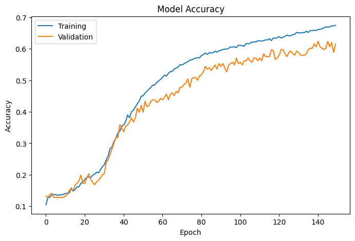

```python
# Display the training accuracy and validation accuracy
show_lineplot(data_train = history_0.history['accuracy'], data_val = history_0.history['val_accuracy'], feature_name = 'Accuracy', labels = ['Training', 'Validation'])
```

```python
# Predict using the training data
y_train_pred_0 = model_0.predict(x_train_nm)

# Predict using the validation data
y_val_pred_0 = model_0.predict(x_val_nm)

# Predict using the testing data
y_test_pred_0 = model_0.predict(x_test_nm)
```

[figure not shown]

```python
# Display the confision matrix using training data
show_confusion_matrix_multiclass(target = np.argmax(y_train_ec, axis = 1), predictors = np.argmax(y_train_pred_0, axis = 1), title = '(Training)')
```

[figure not shown]

```python
# Display the confision matrix using validation data
show_confusion_matrix_multiclass(target = np.argmax(y_val_ec, axis = 1), predictors = np.argmax(y_val_pred_0, axis = 1), title = '(Validation)')
```

[figure not shown]

```python
# Display the confision matrix using testing data
show_confusion_matrix_multiclass(target = np.argmax(y_test_ec, axis = 1), predictors = np.argmax(y_test_pred_0, axis = 1), title = '(Test)')
```

```python
# Display the classification report for training, validation and testing data
show_classification_report(model_name = model_name_0, target_train = np.argmax(y_train_ec, axis = 1), predictors_train = np.argmax(y_train_pred_0, axis = 1), target_val = np.argmax(y_val_ec, axis = 1), predictors_val = np.argmax(y_val_pred_0, axis = 1), target_test = np.argmax(y_test_ec, axis = 1), predictors_test = np.argmax(y_test_pred_0, axis = 1))
```

[output not shown]

**Observations:**

## Model Performance Improvement

### Convolutional Neural Network with Data Augmentation

##### Sequential model with CNN and Data Augmentation using normalized data

```python
# Prepare Data Augmentation using ImageDataGenerator
idg = ImageDataGenerator(
  rotation_range = 90,
  zoom_range = 0.5,
  fill_mode = 'nearest'
)

# Prepare Learning Rate reduction using ReduceLROnPlateau
rlr = ReduceLROnPlateau(
  monitor = 'val_accuracy',
  patience = 3,
  verbose = 1,
  factor = 0.5,
  min_lr = 0.0001
)
```

```python
# Clear backend session
clear_session()

# Create model with CNN and Data Augmentation using normalized data
model_name_1 = 'CNN and Data Augmentation using normalized data'

model_1 = Sequential()

model_1.add(Conv2D(filters = 8, kernel_size = (3, 3), activation = 'relu', padding = 'same', input_shape = (64, 64, 3)))
model_1.add(MaxPooling2D(pool_size = (2, 2), padding = 'same'))

model_1.add(Conv2D(filters = 8, kernel_size = (3, 3), activation = 'relu', padding = 'same'))
model_1.add(MaxPooling2D(pool_size = (2, 2), padding = 'same'))

model_1.add(Conv2D(filters = 8, kernel_size = (3, 3), activation = 'relu', padding = 'same'))
model_1.add(MaxPooling2D(pool_size = (2, 2), padding = 'same'))

model_1.add(Flatten())

model_1.add(Dense(units = 12, activation = 'softmax'))

model_1.compile(optimizer = Adam(learning_rate = 0.0001), loss = 'categorical_crossentropy', metrics = ['accuracy'])

model_1.summary()
```

```
Model: "sequential"
_________________________________________________________________
 Layer (type)                Output Shape              Param #
=================================================================
 conv2d (Conv2D)             (None, 64, 64, 8)         224

 max_pooling2d (MaxPooling2  (None, 32, 32, 8)         0
 D)

 conv2d_1 (Conv2D)           (None, 32, 32, 8)         584

 max_pooling2d_1 (MaxPoolin  (None, 16, 16, 8)         0
 g2D)

 conv2d_2 (Conv2D)           (None, 16, 16, 8)         584

 max_pooling2d_2 (MaxPoolin  (None, 8, 8, 8)           0
 g2D)

 flatten (Flatten)           (None, 512)               0

 dense (Dense)               (None, 12)                6156

=================================================================
Total params: 7548 (29.48 KB)
Trainable params: 7548 (29.48 KB)
Non-trainable params: 0 (0.00 Byte)
_________________________________________________________________
```

```python
%%time

# Fit the model
history_1 = model_1.fit_generator(
  idg.flow(
    x = x_train_nm,
    y = y_train_ec,
    shuffle = False
  ),
  epochs = 150,
  validation_data = (x_val_nm, y_val_ec),
  callbacks = [rlr],
  verbose = 1
)
```

```
CPU times: user 16min 9s, sys: 19.2 s, total: 16min 28s
Wall time: 19min 6s
```

##### Observations on Sequential model with CNN and Data Augmentation using normalized data

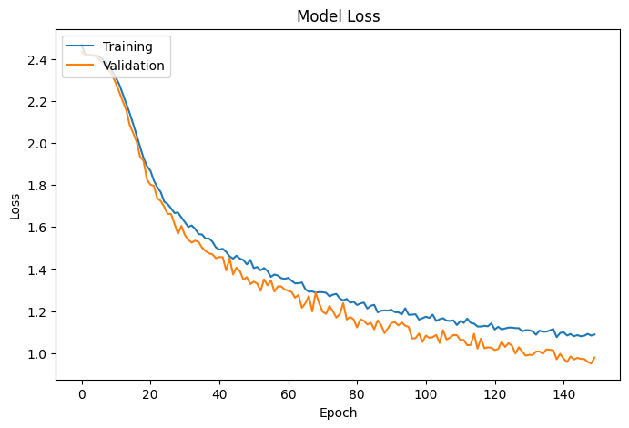

```python
# Display the training loss and validation loss
show_lineplot(data_train = history_1.history['loss'], data_val = history_1.history['val_loss'], feature_name = 'Loss', labels = ['Training', 'Validation'])
```

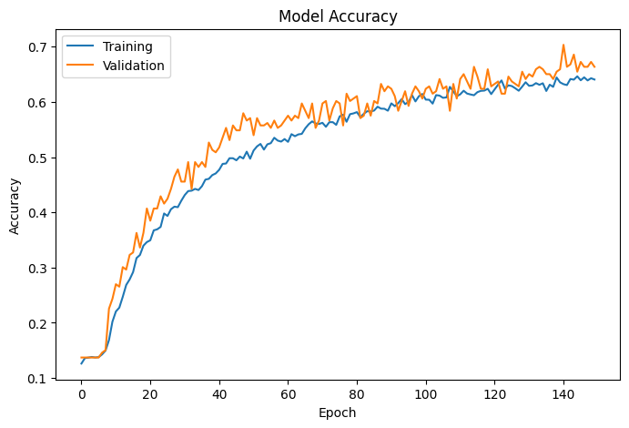

```python
# Display the training accuracy and validation accuracy
show_lineplot(data_train = history_1.history['accuracy'], data_val = history_1.history['val_accuracy'], feature_name = 'Accuracy', labels = ['Training', 'Validation'])
```

```python
# Predict using the training data
y_train_pred_1 = model_1.predict(x_train_nm)

# Predict using the validation data
y_val_pred_1 = model_1.predict(x_val_nm)

# Predict using the testing data
y_test_pred_1 = model_1.predict(x_test_nm)
```

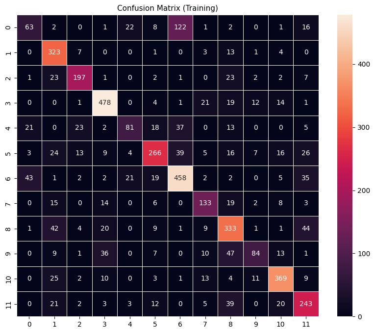

```python
# Display the confision matrix using training data
show_confusion_matrix_multiclass(target = np.argmax(y_train_ec, axis = 1), predictors = np.argmax(y_train_pred_1, axis = 1), title = '(Training)')
```

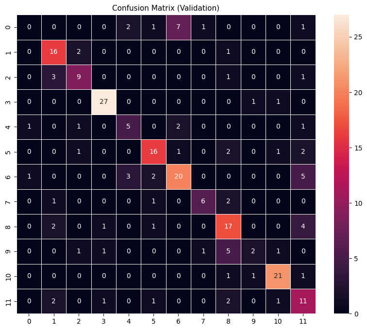

```python
# Display the confision matrix using validation data
show_confusion_matrix_multiclass(target = np.argmax(y_val_ec, axis = 1), predictors = np.argmax(y_val_pred_1, axis = 1), title = '(Validation)')
```

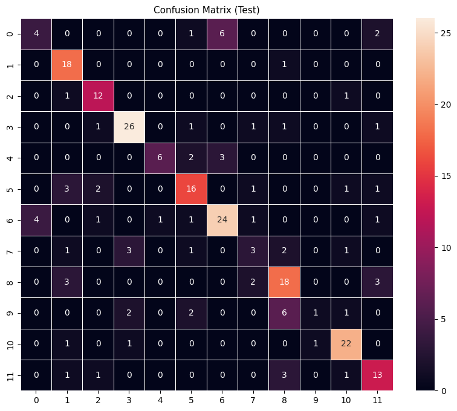

```python
# Display the confision matrix using testing data
show_confusion_matrix_multiclass(target = np.argmax(y_test_ec, axis = 1), predictors = np.argmax(y_test_pred_1, axis = 1), title = '(Test)')
```

```python
# Display the classification report for training, validation and testing data
show_classification_report(model_name = model_name_1, target_train = np.argmax(y_train_ec, axis = 1), predictors_train = np.argmax(y_train_pred_1, axis = 1), target_val = np.argmax(y_val_ec, axis = 1), predictors_val = np.argmax(y_val_pred_1, axis = 1), target_test = np.argmax(y_test_ec, axis = 1), predictors_test = np.argmax(y_test_pred_1, axis = 1))
```

|  | CNN and Data Augmentation using normalized data (Training) precision | CNN and Data Augmentation using normalized data (Training) recall | CNN and Data Augmentation using normalized data (Training) f1-score | CNN and Data Augmentation using normalized data (Training) support | CNN and Data Augmentation using normalized data (Validation) precision | CNN and Data Augmentation using normalized data (Validation) recall | CNN and Data Augmentation using normalized data (Validation) f1-score | CNN and Data Augmentation using normalized data (Validation) support | CNN and Data Augmentation using normalized data (Testing) precision | CNN and Data Augmentation using normalized data (Testing) recall | CNN and Data Augmentation using normalized data (Testing) f1-score | CNN and Data Augmentation using normalized data (Testing) support |
| --- | --- | --- | --- | --- | --- | --- | --- | --- | --- | --- | --- | --- |
| 0 | 0.47727 | 0.26471 | 0.34054 | 238.00000 | 0.00000 | 0.00000 | 0.00000 | 12.00000 | 0.50000 | 0.30769 | 0.38095 | 13.00000 |
| 1 | 0.66598 | 0.91761 | 0.77180 | 352.00000 | 0.66667 | 0.84211 | 0.74419 | 19.00000 | 0.64286 | 0.94737 | 0.76596 | 19.00000 |
| 2 | 0.78175 | 0.76062 | 0.77104 | 259.00000 | 0.64286 | 0.64286 | 0.64286 | 14.00000 | 0.70588 | 0.85714 | 0.77419 | 14.00000 |
| 3 | 0.82986 | 0.86751 | 0.84827 | 551.00000 | 0.90000 | 0.93103 | 0.91525 | 29.00000 | 0.81250 | 0.83871 | 0.82540 | 31.00000 |
| 4 | 0.61832 | 0.40500 | 0.48943 | 200.00000 | 0.50000 | 0.50000 | 0.50000 | 10.00000 | 0.85714 | 0.54545 | 0.66667 | 11.00000 |
| 5 | 0.74930 | 0.62150 | 0.67944 | 428.00000 | 0.72727 | 0.69565 | 0.71111 | 23.00000 | 0.66667 | 0.66667 | 0.66667 | 24.00000 |
| 6 | 0.69394 | 0.77627 | 0.73280 | 590.00000 | 0.66667 | 0.64516 | 0.65574 | 31.00000 | 0.72727 | 0.72727 | 0.72727 | 33.00000 |
| 7 | 0.65842 | 0.66500 | 0.66169 | 200.00000 | 0.75000 | 0.60000 | 0.66667 | 10.00000 | 0.37500 | 0.27273 | 0.31579 | 11.00000 |
| 8 | 0.62830 | 0.71613 | 0.66935 | 465.00000 | 0.54839 | 0.68000 | 0.60714 | 25.00000 | 0.58065 | 0.69231 | 0.63158 | 26.00000 |
| 9 | 0.70000 | 0.40385 | 0.51220 | 208.00000 | 0.50000 | 0.18182 | 0.26667 | 11.00000 | 0.50000 | 0.08333 | 0.14286 | 12.00000 |
| 10 | 0.81457 | 0.82550 | 0.82000 | 447.00000 | 0.84000 | 0.87500 | 0.85714 | 24.00000 | 0.81481 | 0.88000 | 0.84615 | 25.00000 |
| 11 | 0.62308 | 0.69828 | 0.65854 | 348.00000 | 0.42308 | 0.61111 | 0.50000 | 18.00000 | 0.61905 | 0.68421 | 0.65000 | 19.00000 |
| accuracy |  |  | 0.70649 | 4286.00000 |  |  | 0.66372 | 226.00000 |  |  | 0.68487 | 238.00000 |
| macro avg | 0.68673 | 0.66016 | 0.66292 | 4286.00000 | 0.59708 | 0.60039 | 0.58890 | 226.00000 | 0.65015 | 0.62524 | 0.61612 | 238.00000 |
| weighted avg | 0.70273 | 0.70649 | 0.69685 | 4286.00000 | 0.64003 | 0.66372 | 0.64476 | 226.00000 | 0.67465 | 0.68487 | 0.66545 | 238.00000 |

**Observations:**

- Sequential model shows a 70.65% accuracy score on training data, 66.37% accuracy score on validation data and 68.49% accuracy score on testing data using the following parameters:
  - Optimizer = Adam
  - Metrics = Accuracy
  - Learning rate = 0.0001
  - Loss = categorical_crossentropy
  - Total parameters = 7,548
  - Trainable parameters = 7,548
  - Epoch = 150
  - Image generator:
    - Rotation range = 90
    - Zoom range = 0.5
    - Fill mode = nearest
    - Shuffle = False
  - Reduce learning rate:
    - Monitor = val_accuracy
    - Patience = 3,
    - Factor = 0.5,
    - Minimum learning rate = 0.0001
- It took the model approximately 19 minutes and 6 seconds to complete the training.
- The line plot for loss and recall shows slight noise for both training and validation data.
- Most of the wrong predictions are in labels: 4, 9, 0 and 7.

### Transfer Learning with Data Augmentation

##### VGG model with Data Augmentation using normalized data

```python
# Prepare Data Augmentation using ImageDataGenerator
idg = ImageDataGenerator(
  rotation_range = 90,
  zoom_range = 0.5,
  fill_mode = 'nearest'
)

# Prepare Model Checkpoint using ModelCheckpoint
cp = ModelCheckpoint(
  filepath = 'model_2',
  monitor = 'val_accuracy',
  mode = 'max',
  save_best_only = True,
  verbose = 1
)
```

```python
# Clear backend session
clear_session()

# Prepare Transfer Learning using VGG19
vgg = VGG19(weights = 'imagenet', include_top = False, input_shape = (64, 64, 3))

vgg.summary()
```

```
Model: "vgg19"
_________________________________________________________________
 Layer (type)                Output Shape              Param #
=================================================================
 input_1 (InputLayer)        [(None, 64, 64, 3)]       0

 block1_conv1 (Conv2D)       (None, 64, 64, 64)        1792

 block1_conv2 (Conv2D)       (None, 64, 64, 64)        36928

 block1_pool (MaxPooling2D)  (None, 32, 32, 64)        0

 block2_conv1 (Conv2D)       (None, 32, 32, 128)       73856

 block2_conv2 (Conv2D)       (None, 32, 32, 128)       147584

 block2_pool (MaxPooling2D)  (None, 16, 16, 128)       0

 block3_conv1 (Conv2D)       (None, 16, 16, 256)       295168

 block3_conv2 (Conv2D)       (None, 16, 16, 256)       590080

 block3_conv3 (Conv2D)       (None, 16, 16, 256)       590080

 block3_conv4 (Conv2D)       (None, 16, 16, 256)       590080

 block3_pool (MaxPooling2D)  (None, 8, 8, 256)         0

 block4_conv1 (Conv2D)       (None, 8, 8, 512)         1180160

 block4_conv2 (Conv2D)       (None, 8, 8, 512)         2359808

 block4_conv3 (Conv2D)       (None, 8, 8, 512)         2359808

 block4_conv4 (Conv2D)       (None, 8, 8, 512)         2359808

 block4_pool (MaxPooling2D)  (None, 4, 4, 512)         0

 block5_conv1 (Conv2D)       (None, 4, 4, 512)         2359808

 block5_conv2 (Conv2D)       (None, 4, 4, 512)         2359808

 block5_conv3 (Conv2D)       (None, 4, 4, 512)         2359808

 block5_conv4 (Conv2D)       (None, 4, 4, 512)         2359808

 block5_pool (MaxPooling2D)  (None, 2, 2, 512)         0

=================================================================
Total params: 20024384 (76.39 MB)
Trainable params: 20024384 (76.39 MB)
Non-trainable params: 0 (0.00 Byte)
_________________________________________________________________
```

```python
# Set all layers to non-trainable
for layer in vgg.layers:
  layer.trainable = False
```

```python
# Create model with VGG and Data Augmentation using normalized data
model_name_2 = 'VGG w/ Data Aug using normalized data'

model_2 = Sequential()

model_2.add(vgg)

model_2.add(Conv2D(filters = 128, kernel_size = (3, 3), activation = 'relu', padding = 'same'))
model_2.add(MaxPooling2D(pool_size = (2, 2), padding = 'same'))

model_2.add(Conv2D(filters = 128, kernel_size = (3, 3), activation = 'relu', padding = 'same'))
model_2.add(MaxPooling2D(pool_size = (2, 2), padding = 'same'))

model_2.add(Conv2D(filters = 128, kernel_size = (3, 3), activation = 'relu', padding = 'same'))
model_2.add(MaxPooling2D(pool_size = (2, 2), padding = 'same'))

model_2.add(Flatten())

model_2.add(Dense(units = 12, activation = 'softmax'))

model_2.compile(optimizer = Adam(learning_rate = 0.0001), loss = 'categorical_crossentropy', metrics = ['accuracy'])

model_2.summary()
```

```
Model: "sequential_1"
_________________________________________________________________
 Layer (type)                Output Shape              Param #
=================================================================
 vgg19 (Functional)          (None, 2, 2, 512)         20024384

 conv2d_3 (Conv2D)           (None, 2, 2, 128)         589952

 max_pooling2d_3 (MaxPoolin  (None, 1, 1, 128)         0
 g2D)

 conv2d_4 (Conv2D)           (None, 1, 1, 128)         147584

 max_pooling2d_4 (MaxPoolin  (None, 1, 1, 128)         0
 g2D)

 conv2d_5 (Conv2D)           (None, 1, 1, 128)         147584

 max_pooling2d_5 (MaxPoolin  (None, 1, 1, 128)         0
 g2D)

 flatten_1 (Flatten)         (None, 128)               0

 dense_1 (Dense)             (None, 12)                1548

=================================================================
Total params: 20911052 (79.77 MB)
Trainable params: 886668 (3.38 MB)
Non-trainable params: 20024384 (76.39 MB)
_________________________________________________________________
```

```python
%%time

# Fit the model
history_2 = model_2.fit_generator(
  idg.flow(
    x = x_train_nm,
    y = y_train_ec,
    shuffle = False
  ),
  epochs = 300,
  validation_data = (x_val_nm, y_val_ec),
  callbacks = [cp],
  verbose = 1
)
```

```
Epoch 1: val_accuracy improved from -inf to 0.32301, saving model to model_2
Epoch 2: val_accuracy improved from 0.32301 to 0.42035, saving model to model_2
Epoch 3: val_accuracy improved from 0.42035 to 0.44690, saving model to model_2
Epoch 4: val_accuracy improved from 0.44690 to 0.49115, saving model to model_2
Epoch 5: val_accuracy did not improve from 0.49115
Epoch 6: val_accuracy did not improve from 0.49115
Epoch 7: val_accuracy improved from 0.49115 to 0.51327, saving model to model_2
Epoch 8: val_accuracy improved from 0.51327 to 0.52655, saving model to model_2
Epoch 9: val_accuracy did not improve from 0.52655
Epoch 10: val_accuracy improved from 0.52655 to 0.56637, saving model to model_2
Epoch 11: val_accuracy did not improve from 0.56637
Epoch 12: val_accuracy improved from 0.56637 to 0.59292, saving model to model_2
Epoch 13: val_accuracy did not improve from 0.59292
Epoch 14: val_accuracy did not improve from 0.59292
Epoch 15: val_accuracy improved from 0.59292 to 0.60177, saving model to model_2
Epoch 16: val_accuracy did not improve from 0.60177
Epoch 17: val_accuracy did not improve from 0.60177
Epoch 18: val_accuracy did not improve from 0.60177
Epoch 19: val_accuracy did not improve from 0.60177
Epoch 20: val_accuracy did not improve from 0.60177
Epoch 21: val_accuracy did not improve from 0.60177
Epoch 22: val_accuracy did not improve from 0.60177
Epoch 23: val_accuracy did not improve from 0.60177
Epoch 24: val_accuracy did not improve from 0.60177
Epoch 25: val_accuracy did not improve from 0.60177
Epoch 26: val_accuracy did not improve from 0.60177
Epoch 27: val_accuracy did not improve from 0.60177
Epoch 28: val_accuracy improved from 0.60177 to 0.61062, saving model to model_2
Epoch 29: val_accuracy did not improve from 0.61062
Epoch 30: val_accuracy did not improve from 0.61062
Epoch 31: val_accuracy did not improve from 0.61062
Epoch 32: val_accuracy did not improve from 0.61062
Epoch 33: val_accuracy did not improve from 0.61062
Epoch 34: val_accuracy did not improve from 0.61062
Epoch 35: val_accuracy improved from 0.61062 to 0.61504, saving model to model_2
Epoch 36: val_accuracy did not improve from 0.61504
Epoch 37: val_accuracy did not improve from 0.61504
Epoch 38: val_accuracy did not improve from 0.61504
Epoch 39: val_accuracy did not improve from 0.61504
Epoch 40: val_accuracy improved from 0.61504 to 0.62832, saving model to model_2
```

[output cut: 247 more lines]

```
Epoch 288: val_accuracy did not improve from 0.73009
Epoch 289: val_accuracy did not improve from 0.73009
Epoch 290: val_accuracy did not improve from 0.73009
Epoch 291: val_accuracy did not improve from 0.73009
Epoch 292: val_accuracy did not improve from 0.73009
Epoch 293: val_accuracy did not improve from 0.73009
Epoch 294: val_accuracy did not improve from 0.73009
Epoch 295: val_accuracy did not improve from 0.73009
Epoch 296: val_accuracy did not improve from 0.73009
Epoch 297: val_accuracy did not improve from 0.73009
Epoch 298: val_accuracy did not improve from 0.73009
Epoch 299: val_accuracy did not improve from 0.73009
Epoch 300: val_accuracy did not improve from 0.73009
CPU times: user 1h 46min 22s, sys: 1min 59s, total: 1h 48min 22s
Wall time: 1h 46min 2s
```

```python
# Load the model with highest the validation_accuracy using checkpoint
model_2.load_weights('model_2')
```

```
<tensorflow.python.checkpoint.checkpoint.CheckpointLoadStatus at 0x7a13ec617d60>
```

##### Observations on VGG model with Data Augmentation using normalized data

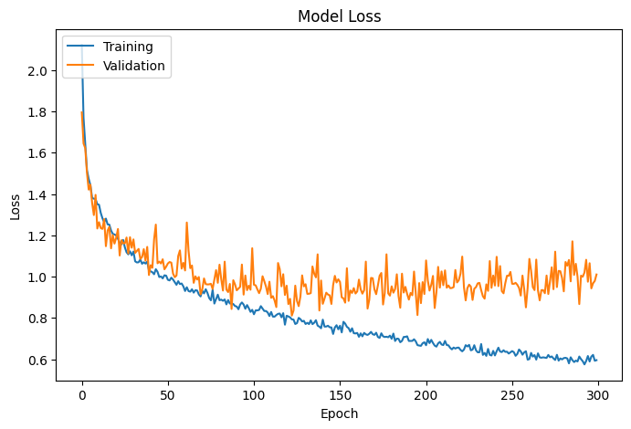

```python
# Display the training loss and validation loss
show_lineplot(data_train = history_2.history['loss'], data_val = history_2.history['val_loss'], feature_name = 'Loss', labels = ['Training', 'Validation'])
```

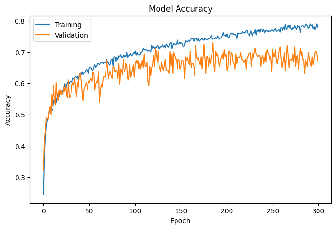

```python
# Display the training accuracy and validation accuracy
show_lineplot(data_train = history_2.history['accuracy'], data_val = history_2.history['val_accuracy'], feature_name = 'Accuracy', labels = ['Training', 'Validation'])
```

```python
# Predict using the training data
y_train_pred_2 = model_2.predict(x_train_nm)

# Predict using the validation data
y_val_pred_2 = model_2.predict(x_val_nm)

# Predict using the testing data
y_test_pred_2 = model_2.predict(x_test_nm)
```

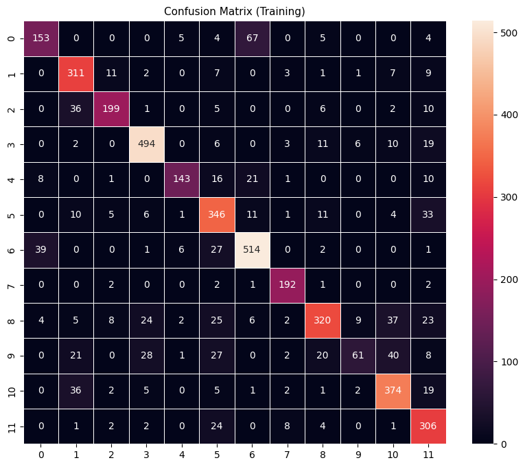

```python
# Display the confision matrix using training data
show_confusion_matrix_multiclass(target = np.argmax(y_train_ec, axis = 1), predictors = np.argmax(y_train_pred_2, axis = 1), title = '(Training)')
```

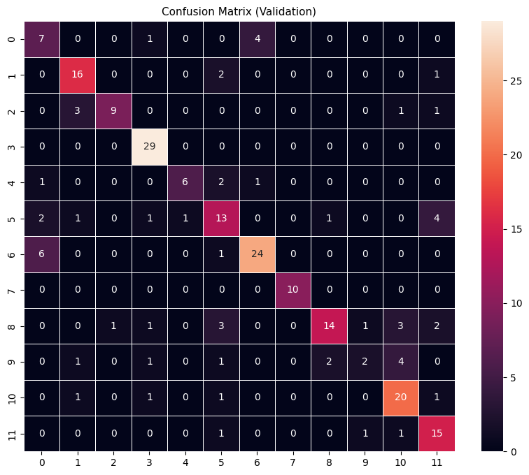

```python
# Display the confision matrix using validation data
show_confusion_matrix_multiclass(target = np.argmax(y_val_ec, axis = 1), predictors = np.argmax(y_val_pred_2, axis = 1), title = '(Validation)')
```

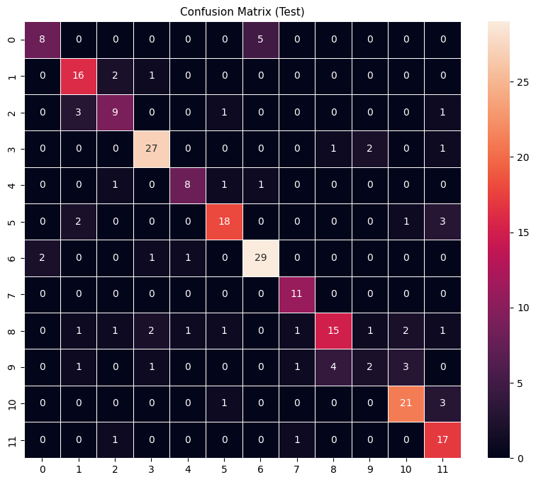

```python
# Display the confision matrix using testing data
show_confusion_matrix_multiclass(target = np.argmax(y_test_ec, axis = 1), predictors = np.argmax(y_test_pred_2, axis = 1), title = '(Test)')
```

```python
# Display the classification report for training, validation and testing data

show_classification_report(model_name = model_name_2, target_train = np.argmax(y_train_ec, axis = 1), predictors_train = np.argmax(y_train_pred_2, axis = 1), target_val = np.argmax(y_val_ec, axis = 1), predictors_val = np.argmax(y_val_pred_2, axis = 1), target_test = np.argmax(y_test_ec, axis = 1), predictors_test = np.argmax(y_test_pred_2, axis = 1))
```

|  | VGG w/ Data Aug using normalized data (Training) precision | VGG w/ Data Aug using normalized data (Training) recall | VGG w/ Data Aug using normalized data (Training) f1-score | VGG w/ Data Aug using normalized data (Training) support | VGG w/ Data Aug using normalized data (Validation) precision | VGG w/ Data Aug using normalized data (Validation) recall | VGG w/ Data Aug using normalized data (Validation) f1-score | VGG w/ Data Aug using normalized data (Validation) support | VGG w/ Data Aug using normalized data (Testing) precision | VGG w/ Data Aug using normalized data (Testing) recall | VGG w/ Data Aug using normalized data (Testing) f1-score | VGG w/ Data Aug using normalized data (Testing) support |
| --- | --- | --- | --- | --- | --- | --- | --- | --- | --- | --- | --- | --- |
| 0 | 0.75000 | 0.64286 | 0.69231 | 238.00000 | 0.43750 | 0.58333 | 0.50000 | 12.00000 | 0.80000 | 0.61538 | 0.69565 | 13.00000 |
| 1 | 0.73697 | 0.88352 | 0.80362 | 352.00000 | 0.72727 | 0.84211 | 0.78049 | 19.00000 | 0.69565 | 0.84211 | 0.76190 | 19.00000 |
| 2 | 0.86522 | 0.76834 | 0.81391 | 259.00000 | 0.90000 | 0.64286 | 0.75000 | 14.00000 | 0.64286 | 0.64286 | 0.64286 | 14.00000 |
| 3 | 0.87744 | 0.89655 | 0.88689 | 551.00000 | 0.85294 | 1.00000 | 0.92063 | 29.00000 | 0.84375 | 0.87097 | 0.85714 | 31.00000 |
| 4 | 0.90506 | 0.71500 | 0.79888 | 200.00000 | 0.85714 | 0.60000 | 0.70588 | 10.00000 | 0.80000 | 0.72727 | 0.76190 | 11.00000 |
| 5 | 0.70040 | 0.80841 | 0.75054 | 428.00000 | 0.54167 | 0.56522 | 0.55319 | 23.00000 | 0.81818 | 0.75000 | 0.78261 | 24.00000 |
| 6 | 0.82770 | 0.87119 | 0.84889 | 590.00000 | 0.82759 | 0.77419 | 0.80000 | 31.00000 | 0.82857 | 0.87879 | 0.85294 | 33.00000 |
| 7 | 0.89720 | 0.96000 | 0.92754 | 200.00000 | 1.00000 | 1.00000 | 1.00000 | 10.00000 | 0.78571 | 1.00000 | 0.88000 | 11.00000 |
| 8 | 0.83770 | 0.68817 | 0.75561 | 465.00000 | 0.82353 | 0.56000 | 0.66667 | 25.00000 | 0.75000 | 0.57692 | 0.65217 | 26.00000 |
| 9 | 0.77215 | 0.29327 | 0.42509 | 208.00000 | 0.50000 | 0.18182 | 0.26667 | 11.00000 | 0.40000 | 0.16667 | 0.23529 | 12.00000 |
| 10 | 0.78737 | 0.83669 | 0.81128 | 447.00000 | 0.68966 | 0.83333 | 0.75472 | 24.00000 | 0.77778 | 0.84000 | 0.80769 | 25.00000 |
| 11 | 0.68919 | 0.87931 | 0.77273 | 348.00000 | 0.62500 | 0.83333 | 0.71429 | 18.00000 | 0.65385 | 0.89474 | 0.75556 | 19.00000 |
| accuracy |  |  | 0.79631 | 4286.00000 |  |  | 0.73009 | 226.00000 |  |  | 0.76050 | 238.00000 |
| macro avg | 0.80387 | 0.77028 | 0.77394 | 4286.00000 | 0.73186 | 0.70135 | 0.70104 | 226.00000 | 0.73303 | 0.73381 | 0.72381 | 238.00000 |
| weighted avg | 0.80167 | 0.79631 | 0.78997 | 4286.00000 | 0.73884 | 0.73009 | 0.72204 | 226.00000 | 0.75363 | 0.76050 | 0.74962 | 238.00000 |

## Model Performance Comparison and Final Model Selection

### Function Definition

```python
# User-defined functions
def show_predicted_image(model, x_data, y_data, lb, index = 0, figsize = (2.2, 2.2)):
  '''
  Description: Function to show the predicted image
  Parameters:
    model: keras.src.engine.sequential.Sequential, required
      The sequential model that will perform the prediction
    x_data: numpy.ndarray, required
      The array of pixels of the feature image data
    y_data: numpy.ndarray, required
      The array of pixels of the label image data
    lb: sklearn.preprocessing.LabelBinarizer, required
      The label binarizer that was used to encode the image data
    index: int, optional
      The index of the image that will be displayed, default: 0
    figsize: tuple, optional
      The figure size in inches, default: (10, 8)
  '''
  plt.figure(figsize = figsize)
  plt.imshow(x_data[index])
  plt.show()

  print('Predicted Label ({}):'.format(index), lb.inverse_transform(model.predict((x_data[index].reshape(1, 64, 64, 3)), verbose = None))[0])
  print('Actual Label ({}):'.format(index), lb.inverse_transform(y_data)[index])
```

### Comparison of Model Performance

##### Comparison of model performance on validation data

```python
# Display the comparison of training accuracy and validation accuracy
metric_train_val_list = [
  (model_name_0, model_0, x_train_nm, y_train_ec, x_val_nm, y_val_ec, None, None),
  (model_name_1, model_1, x_train_nm, y_train_ec, x_val_nm, y_val_ec, None, None),
  (model_name_2, model_2, x_train_nm, y_train_ec, x_val_nm, y_val_ec, None, None)
]

show_model_accuracy_comp(metric_train_val_list)
```

|  | CNN using normalized data | CNN and Data Augmentation using normalized data | VGG w/ Data Aug using normalized data |
| --- | --- | --- | --- |
| Accuracy (Training) | 0.68105 | 0.70649 | 0.79631 |
| Accuracy (Validation) | 0.61504 | 0.66372 | 0.73009 |
| Difference (Training - Validation) | -0.06601 | -0.04277 | -0.06623 |

**Observations:**

- Building the Sequential model with a pre-trained VGG19 model on training data, shows that the following parameters from model **VGG w/ Data Aug using normalized data** is producing the best accuracy score on validation data (with 73.01% accuracy score, and only 6.62% lower than the training accuracy score):
  - Optimizer = Adam
  - Metrics = Accuracy
  - Learning rate = 0.0001
  - Loss = categorical_crossentropy
  - Total parameters = 20,911,052
  - Trainable parameters = 886,668
  - Epoch = 300
  - VGG19 (Pre-trained model):
    - Trainable = False
    - Weights = imagenet
    - Include top = False
    - Input shape = 64, 64, 3
  - Image generator:
    - Rotation range = 90
    - Zoom range = 0.5
    - Fill mode = nearest
    - Shuffle = False
  - Model checkpoint:
    - Monitor = val_accuracy
    - Mode = max
    - Save best only = True

##### Comparison of model performance on testing data

```python
# Display the comparison of training accuracy and testing accuracy
metric_train_test_list = [
  (model_name_0, model_0, x_train_nm, y_train_ec, None, None, x_test_nm, y_test_ec),
  (model_name_1, model_1, x_train_nm, y_train_ec, None, None, x_test_nm, y_test_ec),
  (model_name_2, model_2, x_train_nm, y_train_ec, None, None, x_test_nm, y_test_ec)
]

show_model_accuracy_comp(metric_train_test_list)
```

|  | CNN using normalized data | CNN and Data Augmentation using normalized data | VGG w/ Data Aug using normalized data |
| --- | --- | --- | --- |
| Accuracy (Training) | 0.68105 | 0.70649 | 0.79631 |
| Accuracy (Testing) | 0.63445 | 0.68487 | 0.76050 |
| Difference (Training - Testing) | -0.04660 | -0.02161 | -0.03581 |

**Observations:**

- Building the Sequential model with a pre-trained VGG19 model on training data, shows that the following parameters from model **VGG w/ Data Aug using normalized data** is producing the best accuracy score on testing data (with 76.05% accuracy score, and only 3.58% lower than the training accuracy score):
  - Optimizer = Adam
  - Metrics = Accuracy
  - Learning rate = 0.0001
  - Loss = categorical_crossentropy
  - Total parameters = 20,911,052
  - Trainable parameters = 886,668
  - Epoch = 300
  - VGG19 (Pre-trained model):
    - Trainable = False
    - Weights = imagenet
    - Include top = False
    - Input shape = 64, 64, 3
  - Image generator:
    - Rotation range = 90
    - Zoom range = 0.5
    - Fill mode = nearest
    - Shuffle = False
  - Model checkpoint:
    - Monitor = val_accuracy
    - Mode = max
    - Save best only = True

### Visualizing the Prediction

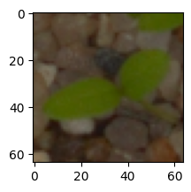

```
Predicted Label (87): Common Chickweed
Actual Label (87): Common Chickweed
```

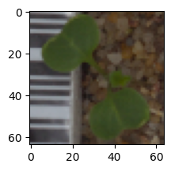

```
Predicted Label (98): Charlock
Actual Label (98): Charlock
```

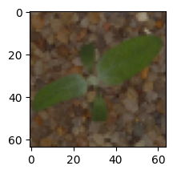

```
Predicted Label (23): Fat Hen
Actual Label (23): Fat Hen
```

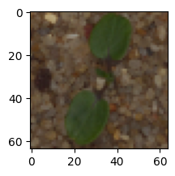

```
Predicted Label (101): Cleavers
Actual Label (101): Cleavers
```

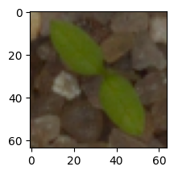

```
Predicted Label (204): Common Chickweed
Actual Label (204): Common Chickweed
```

```python
# Display the image of the predicted plant using the testing data
show_predicted_image(model_2, x_test_nm, y_test_ec, lb, random.randint(0, x_test_nm.shape[0]))

# Display the image of the predicted plant using the testing data
show_predicted_image(model_2, x_test_nm, y_test_ec, lb, random.randint(0, x_test_nm.shape[0]))

# Display the image of the predicted plant using the testing data
show_predicted_image(model_2, x_test_nm, y_test_ec, lb, random.randint(0, x_test_nm.shape[0]))

# Display the image of the predicted plant using the testing data
show_predicted_image(model_2, x_test_nm, y_test_ec, lb, random.randint(0, x_test_nm.shape[0]))

# Display the image of the predicted plant using the testing data
show_predicted_image(model_2, x_test_nm, y_test_ec, lb, random.randint(0, x_test_nm.shape[0]))
```

**Observations:**

- The model **VGG w/ Data Aug using normalized data** shows it can correctly predict the type of plant from the testing data.

### Key Observations on Model Comparison

- The model **VGG w/ Data Aug using normalized data** shows the highest accuracy scores in training, validation and testing data:
  - Training: 79.63%
  - Validation: 73.01%
  - Testing: 76.05%
- We will choose the model **VGG w/ Data Aug using normalized data** as the best model since it shows the highest accuracy scores. The model was tuned using the following parameters:
  - Optimizer = Adam
  - Metrics = Accuracy
  - Learning rate = 0.0001
  - Loss = categorical_crossentropy
  - Total parameters = 20,911,052
  - Trainable parameters = 886,668
  - Epoch = 300
  - VGG19 (Pre-trained model):
    - Trainable = False
    - Weights = imagenet
    - Include top = False
    - Input shape = 64, 64, 3
  - Image generator:
    - Rotation range = 90
    - Zoom range = 0.5
    - Fill mode = nearest
    - Shuffle = False
  - Model checkpoint:
    - Monitor = val_accuracy
    - Mode = max
    - Save best only = True

## Actionable Insights and Business Recommendations

### Conclusions:

- The model **VGG w/ Data Aug using normalized data** provides an accuracy score of 79.63% for the training data, 73.01% for the validation data and 76.05% for the testing data.
- As observed in the visualization during the final model selection, the model can correctly predict the type of plant from the testing data.

### Recommendations:

- Additional data must be provided to obtain more reliable results. This can also solve the imbalanced data for the following minority classes:
  - Maize (with 221 or 4.65%)
  - Common wheat (with 221 or 4.65%)
  - Shepherds Purse (with 231 or 4.86%)
  - Black-grass (with 263 or 5.53%)
  - Cleavers (with 287 or 6.04%)
- Recapturing the images with small plants (or with blurred images) is needed to improve the accuracy of the predictions.
- Collaborate with other organizations in the agricultural industry to help produce high-quality and labeled datasets.
- Add more plant species to make it more general purpose. This will reduce the time and effort to sort and identify other plant species.